# PML_Course_Project

asamuelson

August 7, 2016

This report details an effort to predict the quality of exercise performed by study participants by using a machine learning algorithm. The data comes from the study cited below.

Velloso, E.; Bulling, A.; Gellersen, H.; Ugulino, W.; Fuks, H. Qualitative Activity Recognition of Weight Lifting Exercises. Proceedings of 4th International Conference in Cooperation with SIGCHI (Augmented Human ’13). Stuttgart, Germany: ACM SIGCHI, 2013.

The training data and test cases from the CSV files were imported into R using read.csv and split into training and testing sets for purposes of model validation and out of sample error estimation. The training set contained 70% of the original data and the testing set contained the other 30%.

```r
library(caret)
training <- read.csv("pml-training.csv")
classes <- sapply(training, class)
testing <- read.csv("pml-testing.csv", colClasses = c("character", classes[2:159]))
inTrain <- createDataPartition(training$classe, p = 0.7, list = FALSE)
trainingSet <- training[inTrain, ]
testingSet <- training[-inTrain, ]
```

The first seven columns of the dataset did not contain measurement information on the exercises performed in the study and were therefore omitted as predictors in the model. The function nearZeroVar was used to determine variables which had little variance. These variables were then omitted as predictors in an effort to streamline the model.

The model was built using the train function in the caret package in R. The train functionallows calls to a variety of different machine learning algorithms. For this model,after some experimentation with different methods, the random forest method was selected for its high accuracy. This model uses a random forest with 500 trees and k nearest neighbor imputation preprocessing to handle the missing values in the dataset. The random forest fit the model using the 93 predictors which remained after the seemingly irrelevant and near zero variance variables were removed. The preprocessing was necessary for the random forest to be able to handle the dataset, as there were many missing values.

```r
nearzerovars <- nearZeroVar(training)
x <- trainingSet[ ,-c(1:7, nearzerovars, 160)]
y <- trainingSet[ ,160]
ctrl <- trainControl(method = "repeatedcv")
modFit <- train(x = x, y = y,  method = "rf", preProcess = "knnImpute", trControl = ctrl)
```

Figure 1 shows the accuracy of the model based on the number of predictors evaluated at each step, with an optimal value of 47. Figure 2 shows the model error based on the number of trees. It seems that the model accuracy is only marginally improved by adding more trees once 50 or so trees are in the model.

```r
print(modFit$finalModel)
```

```
##
## Call:
##  randomForest(x = x, y = y, mtry = param$mtry)
##                Type of random forest: classification
##                      Number of trees: 500
## No. of variables tried at each split: 47
##
##         OOB estimate of  error rate: 0.84%
## Confusion matrix:
##      A    B    C    D    E class.error
## A 3900    5    1    0    0 0.001536098
## B   16 2625   16    1    0 0.012415350
## C    1   18 2366   11    0 0.012520868
## D    1    1   31 2216    3 0.015985790
## E    0    2    5    4 2514 0.004356436
```

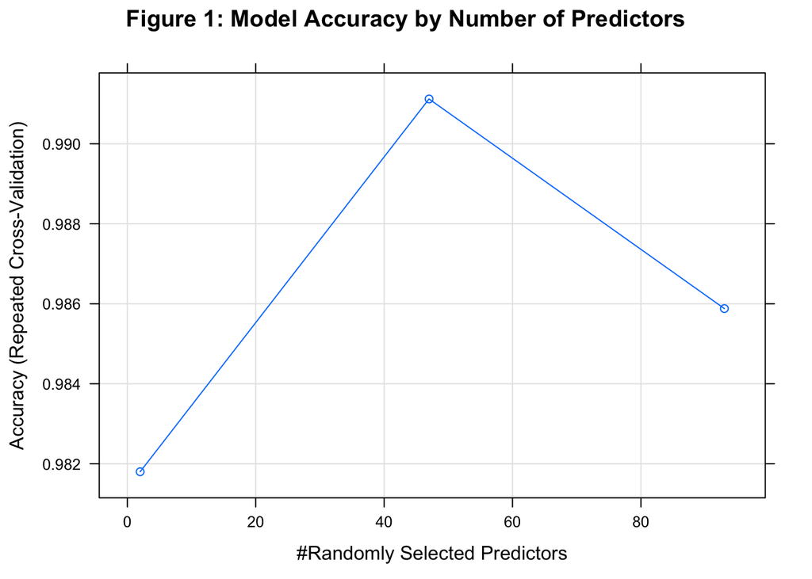

```r
plot(modFit, main = "Figure 1: Model Accuracy by Number of Predictors")
```

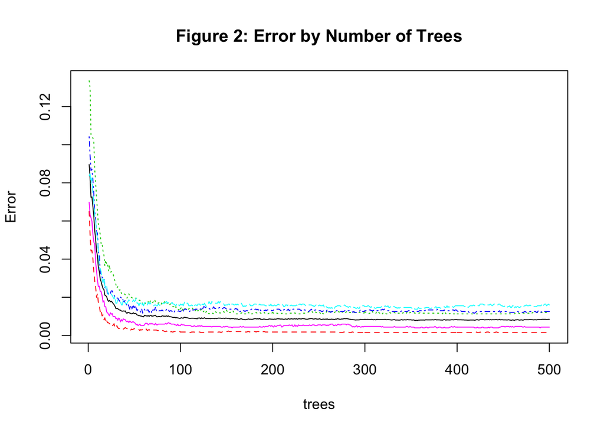

```r
plot(modFit$finalModel, main = "Figure 2: Error by Number of Trees")
```

The following table shows the accuracy of the predicted values for the test set derived from the original training data. The test set was restricted to the same predictors as the training set.

```r
w <- testingSet[ ,-c(1:7, nearzerovars, 160)]
z <- testingSet[ ,160]
pred <- predict(modFit, w)
table(pred, z)
```

```
##     z
## pred    A    B    C    D    E
##    A 1671    5    0    0    0
##    B    0 1131   14    1    2
##    C    1    3 1003   12    1
##    D    0    0    9  947    2
##    E    2    0    0    4 1077
```

Below the predictions for the 20 unknown test cases are shown. All 20 predicted values were verified as correct on the prediction quiz.

```r
testSet <- testing[ ,-c(1:7, nearzerovars, 160)]
predict(modFit, testSet)
```

```
##  [1] B A B A A E D B A A B C B A E E A B B B
## Levels: A B C D E
```